# STAT565 Homework

Winter 2019

## HW0

### Problem 1 (2.1)

Compute the values of the missing quantities.

| Variable | N | Mean | SE Mean | Std. Dev. | Variance | Minimum | Maximum |
| --- | --- | --- | --- | --- | --- | --- | --- |
| Y | 9 | 19.96 | ? | 3.12 | ? | 15.94 | 27.16 |

$$\text{SE mean}=\frac{Std.Dev.}{\sqrt{n}}=\frac{3.12}{\sqrt9}=1.04$$

$$Var(Y)=S^2=3.12^2=9.7344$$

### Problem 2 (2.17/19)

The viscosity of a liquid detergent is supposed to average 800 centistokes at 25∘C. A random sample of 16 batches of detergent is collected, and the average viscosity is 812. Suppose we know that the standard deviation of viscosity is σ = 25 centistokes.

1. State the hypotheses that should be tested. Let $\mu=800, \bar y=812, n=16, σ=25$

$$H_0: \mu=800\qquad H_A: \mu\neq800$$

2. Test these hypotheses using 𝛼 = 0.05. What are your conclusions?

Assuming the population is normal, the sample size is less than 30 but the variance is known. The hypothesis may be tested using a direct application of the normal distribution.

$$se(\hat\mu)=\frac{σ}{\sqrt{n}}=\frac{25}{\sqrt{16}}=6.25$$

$$Z_0=\frac{\bar y-\mu}{se(\hat\mu)}=\frac{812-800}{6.25}=1.92$$

Since $Z_{\frac{α}2} =Z_{0.025}=1.96$, do not reject.

3. What is the P-value for the test?

The P-value is below:

```r
2*(1-pnorm(812, mean = 800, sd = 25/4, lower.tail = TRUE, log.p = FALSE))
```

```
## [1] 0.0548579
```

```r
2*pnorm(-1.92)
```

```
## [1] 0.0548579
```

4. Find a 95 percent confidence interval on the mean.

$$\bar y-Z_{\frac{α}2}se(\mu)\le\mu\le\bar y+Z_{\frac{α}2}se(\mu)\implies 812-1.96\times6.25\le\mu\le812+1.96\times6.25$$

$$\implies 799.75\le\mu\le824.25$$

### Problem 3

The simple linear regression model: $y_i=β_0+β_1 x_i+ε$, $E(ε_i)=0$, $Var(ε_i)=\sigma^2$, for $i=1,2,…,n$; $Cov(ε_i,ε_j)=0$ for $i≠j$, $x_i=\begin{cases}0& \text{for Male for }i=1,2,…,\frac{n}2\\1& \text{for Female for}\frac{n}2+1,\frac{n}2+2,..n\end{cases}$

Use the least squares method to find the estimated value of $β_1$ and simplify your answer as much as possible. Show all the steps of your work.

For $ε_i\sim iid N(0, \sigma^2), i=1,2,…,n$,

$S(\beta_0,\beta_1)=\sum_{i=1}^n\varepsilon_i=\sum_{i=1}^n(y_i-\beta_0-\beta_1x_i)^2$

$$\left.\frac{\partial S}{\partial\beta_0}\right|_{\hat\beta_0,\hat\beta_1}=2\sum_{i=1}^n(y_i-\hat\beta_0-\hat\beta_1x_i)(-1)=0$$
$$\left.\frac{\partial S}{\partial\beta_1}\right|_{\hat\beta_0,\hat\beta_1}=2\sum_{i=1}^n(y_i-\hat\beta_0-\hat\beta_1x_i)(-x_i)=0$$

- Normal Equations

$$\sum_{i=1}^ny_i=n\hat\beta_0+\hat\beta_1\sum_{i=1}^nx_i$$
$$\sum_{i=1}^nx_iy_i=\hat\beta_0\sum_{i=1}^nx_i+\hat\beta_1\sum_{i=1}^nx_i^2$$

For a indicator variable $x_i$,

$\sum_{i=1}^nx_i=\sum_{i=1}^nx_i^2=\sum_{i=1}^{\frac{n}2}0+\sum_{i=\frac{n}2+1}^n1=\frac{n}2$,

$\sum_{i=1}^nx_iy_i=\sum_{i=1}^{\frac{n}2}0y_i+\sum_{i=\frac{n}2+1}^n1y_i=\sum_{i=\frac{n}2+1}^ny_i$, and

$E[\bar y]=E[\frac{\sum_{i=1}^ny_i}n]=\mu$, $n\bar y=\sum_{i=1}^ny_i$, then the normal equations are

$$\bar y= \hat\beta_0+\frac{\hat\beta_1}2;\quad \sum_{i=\frac{n}2+1}^ny_i=\frac{n}2(\hat\beta_0+\hat\beta_1)$$

$$\therefore\frac2n\sum_{i=\frac{n}2+1}^ny_i=(\bar y-\frac{\hat\beta_1}2)+\hat{\beta_1}\implies\hat{\beta_1}=\frac4n\sum_{i=\frac{n}2+1}^ny_i-2\bar y$$

### Problem 4 (2.30/32)

1. Is there evidence to support the claim that the longer cool-down time results in fewer appearance defects? Use 𝛼 = 0.05.

We use the paired t-test because the observations from the factor levels are “paired” on each experimental unit.

In order to test the claim that the longer cool-down time results in fewer appearance defects on average, the hypotheses are $H_0:\mu_{20-10}\le0;\quad H_1:\mu_{20-10}>0$.

```r
t.test(table_cellphone$TwentySeconds, table_cellphone$TenSeconds, paired = T,var.equal=T, alternative="greater", mu = 0, conf.level= 0.95)
```

```
##
##  Paired t-test
##
## data:  table_cellphone$TwentySeconds and table_cellphone$TenSeconds
## t = 5.5927, df = 19, p-value = 1.077e-05
## alternative hypothesis: true difference in means is greater than 0
## 95 percent confidence interval:
##  2.176087      Inf
## sample estimates:
## mean of the differences
##                    3.15
```

P-value is less than significance level (5%) and null hypothesis ($H_0$) is rejected. Therefore, we can be 95% sure the housings with 20 seconds of cool-down times have a higher means of scores than 10 seconds at least 2.176087.

2. What is the P-value for the test conducted in part (a)?

p-value = $1.077\times10^{-05}$

3. Find a 95 percent confidence interval on the difference in means. Provide a practical interpretation of this interval.

In order to test the 95 percent confidence interval on the difference in means, the hypotheses are $H_0:\mu_{20-10}=0;\quad H_1:\mu_{20-10}\neq0$.

```r
t.test(score~cool_down_time, data=gather(table_cellphone,key=cool_down_time,value=score), paired = T,var.equal=T, alternative="two.sided", mu = 0, conf.level= 0.95)
```

```
##
##  Paired t-test
##
## data:  score by cool_down_time
## t = -5.5927, df = 19, p-value = 2.154e-05
## alternative hypothesis: true difference in means is not equal to 0
## 95 percent confidence interval:
##  -4.32887 -1.97113
## sample estimates:
## mean of the differences
##                   -3.15
```

P-value is less than significance level (5%) and the 95% confidence bound is negative (-4.32887 -1.97113). Therefore, the null hypothesis ($H_0$) is rejected. We can be 95% confidence that the difference in average scores of housing with 10 seconds and 20 seconds of cool-down times is between -4.32887 and -1.97113. In other words, we can conclude that the scores of housings with 10-second and 20-second cool-down times are significantly different at 5% significance level.

## HW1

### Problem 1

In a greenhouse experiment, 5 types of light were used: natural, white, green, blue, and yellow. Eight tobacco plants, each 10 mm tall, were subjected to each type of light with the following means and variances of stem growths (in mm).

| Color | Natural | White | Yellow | Blue | Green |
| --- | --- | --- | --- | --- | --- |
| Mean | 4.09 | 4.30 | 3.55 | 3.01 | 3.19 |
| Variance | 0.027 | 0.083 | 0.066 | 0.030 | 0.073 |

A partial ANOVA table was found to be

| Source of Variance | Sum of Squares(SS) | Degrees of Freedom(df) | Mean Squares(MS) | F test statistic |
| --- | --- | --- | --- | --- |
| Treatment(Between or Model) | 9.95904 | 4 | 2.48976 | 44.688 |
| Error(Within) | 1.950 | 35 | 0.05571429 |  |
| Total | 11.90904 | 39 |  |  |

1. Complete the ANOVA table assuming the one-way fixed effects ANOVA model. Show main steps of your work. Keep 3 decimal places in $SS_{Trt}$

For $a=5,n=8$, $df_T=N-1=5\times8-1=39$, $df_{Trt}=5-1=4$, $df_E=N-a=35$

$\bar y_{..}=\frac{1}a\sum^a_{i=1}\bar y_{i.}=\frac{1}5(4.09+4.30+3.55+3.01+3.19)=3.628$

$SS_{Trt}=n\sum^a_{i=1}(\bar y_{i.}−\bar y_{..})^2=9.95904$; $SS_{T}=SS_{Trt}+SS_{E}=11.90904$;

$MS_{Trt}=\frac{SS_{Trt}}{a-1}=\frac{9.95904}4=2.48976$; $MS_{E}=\frac{SS_{E}}{N-a}=\frac{1.950}{35}=0.05571429$;

$F_{0}=\frac{MS_{Trt}}{MS_{E}}=\frac{2.48976}{0.05571429}=44.688$

2. Compute the standard error of the difference of two observed treatment means. (that is, compute $se(\bar y _{i.}-\bar y_{j.})$) Show main steps of your work.

$$se(\bar y _{i.}-\bar y_{j.})=\sqrt{\frac{2MSE}n}=\sqrt{\frac{2\times0.05571429}8}=0.1180194$$

### Problem 2 (3.37/45)

Exercise 3.37. Assume n_i is the number of observations (replications) for the $i^th$ treatment in the one-way ANVOA. Show main steps of work. Show that the variance of the linear combination $\sum^{a}_{i=1}c_iy_{i.}$ is $σ^2\sum^{a}_{i=1}n_ic_i^2$

By the assumption for linear combination,$c_i$ is contrast constants. This is an unbalanced CRD, $\mu_i$ is not random. For $ε_{ij}\sim iid\ N(0,σ^2)$ and are uncorrelated, $Var(ε_{ij})=\sigma^2$. Thus,

$$Var\left[\sum^{a}_{i=1}c_iy_{i.}\right]=\sum^{a}_{i=1}\left[c_i^2Var(\sum^{n_i}_{j=1}y_{ij})\right]=\sum^{a}_{i=1}\left[c_i^2Var(\sum^{n_i}_{i=1}(\mu_i+ε_{ij}))\right]=\sum^{a}_{i=1}\left[c_i^2\sum^{n_i}_{j=1}Var(ε_{ij})\right]=\sum^{a}_{i=1}\left[c_i^2n_i\sigma^2\right]=σ^2\sum^{a}_{i=1}n_ic_i^2$$

### Problem 3

Let $y_{ij}=\mu+\tau_{i}+\varepsilon_{ij}, ε_{ij}\sim iid\ N(0,σ^2)$,for $i=1,2,…,a;\ j=1,2,…,n$;$\sum_{i=1}^a\tau_i=0$, $\bar y_{i.}=\frac1n \sum_{j=1}^ny_{ij}$, $\bar y_{i.}\sim iid\ N(\mu+\tau_i,\frac{\sigma^2}n)$

1. Using ONLY the above given information and properties of expected value of a function of random variables, derive (DO NOT use any other distribution properties)

For a fixed effects model, $\mu$ is a constant and $\tau_i$ is a constant of the $i^{th}$ treatment, then

$y_{ij}-\bar y_{i.}=\mu+\tau_{i}+\varepsilon_{ij}-\frac1n \sum_{j=1}^n(\mu+\tau_{i}+\varepsilon_{ij})=\mu+\tau_{i}+\varepsilon_{ij}-\mu-\tau_{i}-\frac1n \sum_{j=1}^n\varepsilon_{ij}=\varepsilon_{ij}-\frac1n \sum_{j=1}^n\varepsilon_{ij}$

For $ε_{ij}\sim iid\ N(0,σ^2)$, $E[\varepsilon_{ij}]=0$

$$E(y_{ij}-\bar y_{i.})=E[\varepsilon_{ij}-\frac1n \sum_{j=1}^n\varepsilon_{ij}]=E[\varepsilon_{ij}]-\frac1n \sum_{j=1}^nE[\varepsilon_{ij}]=0$$

$Var(y_{ij}-\bar y_{i.})=Var[\varepsilon_{ij}-\frac1n \sum_{j=1}^n\varepsilon_{ij}]=Var[\varepsilon_{ij}]+\frac1{n^2}\sum_{j=1}^nVar[\varepsilon_{ij}]-\frac2nCov[\varepsilon_{ij},\sum_{j=1}^n\varepsilon_{ij}]$

For $ε_{ij}\sim iid\ N(0,σ^2)$, $Var[\varepsilon_{ij}]=Cov[\varepsilon_{ij},\varepsilon_{ij}]=\sigma^2$, $Cov[\varepsilon_{ij},\varepsilon_{ik}]=0,k\neq j$ then

$-\frac2nCov[\varepsilon_{ij},\sum_{j=1}^n\varepsilon_{ij}]=-\frac2nCov[\varepsilon_{ij},(\varepsilon_{i1}+..+\varepsilon_{ij}..+\varepsilon_{in})]=-\frac2n(Cov[\varepsilon_{ij},\varepsilon_{i1}]+..+Cov[\varepsilon_{ij},\varepsilon_{ij}]..+Cov[\varepsilon_{ij},\varepsilon_{in}])=-\frac2n\sigma^2$

$$Var(y_{ij}-\bar y_{i.})=\sigma^2+\frac{\sigma^2}n-\frac2n\sigma^2=\frac{n-1}n\sigma^2$$

2. Using your answers in part (a) and shortcut formula for variance ($Var(X)=E(X^2)-E(X)^2$), find $E[(y_{ij}-\bar y_{i.})^2]$

For $Var[y_{ij}-\bar y_{i.}]=E[(y_{ij}-\bar y_{i.})^2]-E[y_{ij}-\bar y_{i.}]^2$, then

$$E[(y_{ij}-\bar y_{i.})^2]=Var[y_{ij}-\bar y_{i.}]+E[y_{ij}-\bar y_{i.}]^2=\frac{n-1}n\sigma^2$$

3. Let $a=3$ treatments in the above model and the following linear functions of $\mu_i=\mu+\tau_i$ are tested. $\mu_1=\mu_2$, $\frac{\mu_1+\mu_2}{2}=\mu_3$.
4. Prove that each of these is a contrast and they are orthogonal contrasts.

For $a=3,\mu_1=\mu_2$, let $c_1=1,c_2=-1,c_3=0$. For $\frac{\mu_1+\mu_2}2=\mu_3$, let $d_1=1,d_2=1,d_3=-2$

$$\sum_{i=1}^3c_i=1-1+0=0;\quad\sum_{i=1}^3d_i=1+1-2=0$$

$$\sum_{i=1}^3c_id_i=1*1+(-1)*1+(-2)*0=0$$

Therefore, they are orthogonal contrasts.

2. Write Sum of Squares for each contrast $SS_c$ in terms of $y_{1.},y_{2.},y_{3.}$.

$$SS_c=\frac{C^2}{\frac1n\sum_{i=1}^ac_i^2}=\frac{(\sum_{i=1}^ac_i\bar y_{i.})^2}{\frac1n\sum_{i=1}^ac_i^2}=\begin{cases}\frac{(\bar y_{1.}-\bar y_{2.})^2}{\frac{1+1}n}=\frac{n(\bar y_{1.}-\bar y_{2.})^2}{2}
&for\ \mu_1=\mu_2\\
\frac{(\bar y_{1.}+\bar y_{2.}-2\bar y_{3.})^2}{\frac{1+1+4}n}=\frac{n(\bar y_{1.}+\bar y_{2.}-2\bar y_{3.})^2}{6}
&for\ \frac{\mu_1+\mu_2}{2}=\mu_3
\end{cases}$$

3. Add the two $SS_c$ you found in part (ii) and simplify (expand and bring similar terms together).

$SS_c=\frac{n(\bar y_{1.}-\bar y_{2.})^2}{2}+\frac{n(\bar y_{1.}+\bar y_{2.}-2\bar y_{3.})^2}{6}=\frac{n}6(4\bar y_{1.}^2+4\bar y_{2.}^2+4\bar y_{3.}^2-4\bar y_{1.}\bar y_{2.}-4\bar y_{2.}\bar y_{3.}-4\bar y_{1.}\bar y_{3.})$

Then expand and simplify the $SS_{Trt}$ given below to prove that it is equivalent to the sum of two $SS_c$ you found earlier.

$SS_{Trt}=n\sum_{i=1}^3(\bar y_{i.}-\bar y_{..})^2=\frac{n}9\sum_{i=1}^3(3\bar y_{i.}-\bar y_{1.}-\bar y_{2.}-\bar y_{3.})^2=\frac{n}9[(2\bar y_{1.}-\bar y_{2.}-\bar y_{3.})^2+(2\bar y_{2.}-\bar y_{1.}-\bar y_{3.})^2+(2\bar y_{3.}-\bar y_{1.}-\bar y_{2.})^2]$ $=\frac{n}9[6\bar y_{1.}^2+6\bar y_{2.}^2+6\bar y_{3.}^2-6\bar y_{1.}\bar y_{2.}-6\bar y_{2.}\bar y_{3.}-6\bar y_{1.}\bar y_{3.}]$

$$\therefore SS_c=SS_{Trt}=\frac{2n}3(\bar y_{1.}^2+\bar y_{2.}^2+\bar y_{3.}^2-\bar y_{1.}\bar y_{2.}-\bar y_{2.}\bar y_{3.}-\bar y_{1.}\bar y_{3.})$$

### Problem 4 (3.26/30)

Use software to do all the computations, and attach code and output at the end of the question. If your answers rely on graphs, please include them along with the answer appropriately Report p-value along with your conclusions Data are given in Exercise3_26 Excel file .

1. Are the lives of these brands of batteries different?

The relevant overall hypotheses are $H_0: \mu_1=\mu_2=\mu_3, H_1:$ at lesat two of $\mu_i$ are different.

The ANOVA result shows that p-value of F-test ($6.141\times10^{-6}$) is small enough to reject $H_0$. We can conclude there is a significant differce in treatment means or these brands have an effect on the life of battery on 0.05 significent level.

```r
table_battery <- read_xlsx("Exercise3_26.xlsx")
model_battery <- aov(Life~Brand, data=table_battery)
summary(model_battery)
##             Df Sum Sq Mean Sq F value   Pr(>F)
## Brand        2 1196.1   598.1   38.34 6.14e-06 ***
## Residuals   12  187.2    15.6
## ---
## Signif. codes:  0 '***' 0.001 '**' 0.01 '*' 0.05 '.' 0.1 ' ' 1
```

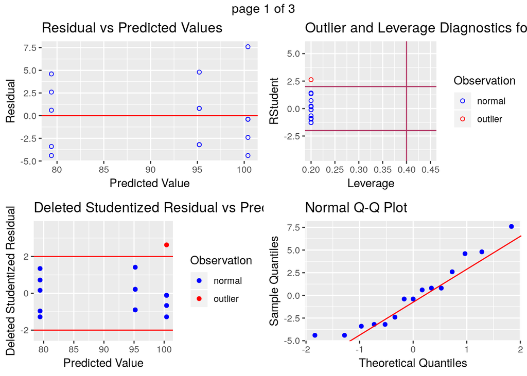

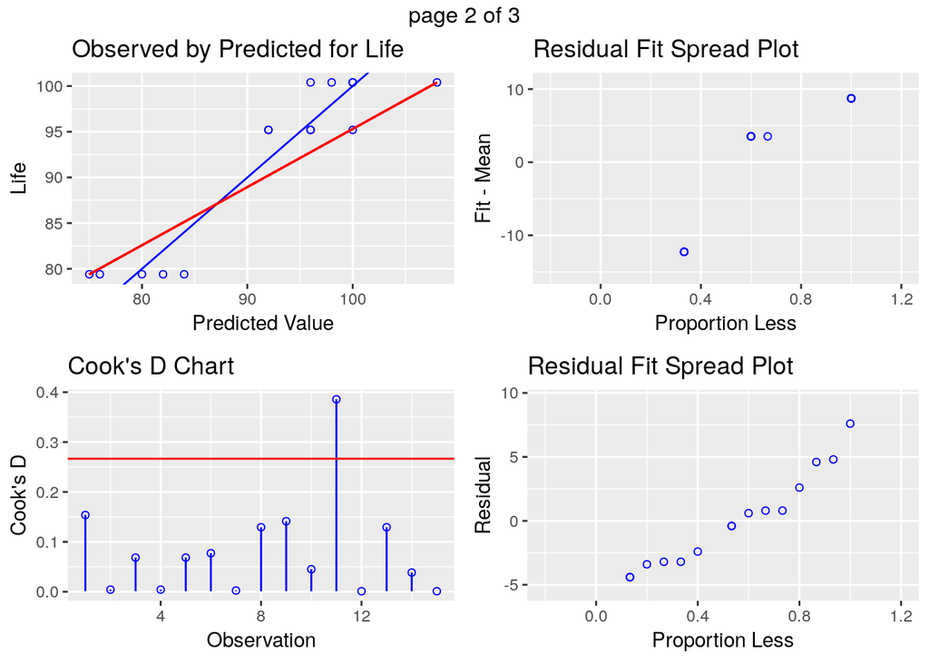

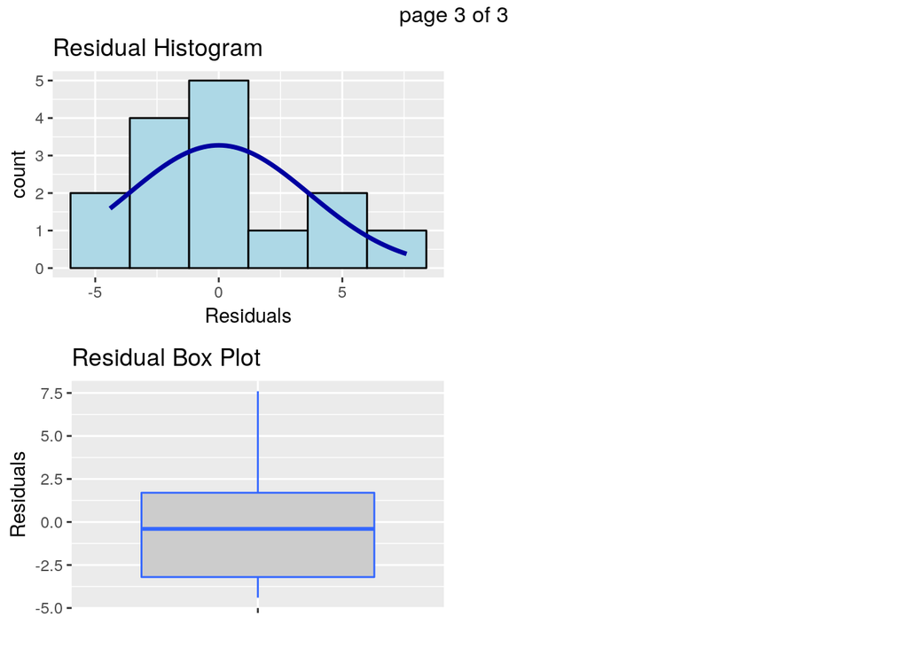

```r
ols_plot_diagnostics(lm(Life~Brand, data=table_battery))
```

```r
bartlett.test(Life~Brand, data=table_battery)
##
##  Bartlett test of homogeneity of variances
##
## data:  Life by Brand
## Bartlett's K-squared = 0.34675, df = 2, p-value = 0.8408
```

3. Construct a 95 percent confidence interval estimate on the mean life of battery brand 2. Construct a 99 percent confidence interval estimate on the mean difference between the lives of battery brands 2 and 3.

Therefore, $75.551\le\mu_2\le83.249$, $-28.631\le\mu_2-\mu_3\le-13.369$

```r
(LSD.test(model_battery, trt="Brand",alpha = 0.05))
## $statistics
##   MSerror Df     Mean       CV  t.value      LSD
##      15.6 12 91.66667 4.308746 2.178813 5.442673
##
## $parameters
##         test p.ajusted name.t ntr alpha
##   Fisher-LSD      none  Brand   3  0.05
##
## $means
##         Life      std r      LCL       UCL Min Max Q25 Q50 Q75
## Brand1  95.2 3.346640 5 91.35145  99.04855  92 100  92  96  96
## Brand2  79.4 3.847077 5 75.55145  83.24855  75  84  76  80  82
## Brand3 100.4 4.560702 5 96.55145 104.24855  96 108  98 100 100
##
## $comparison
## NULL
##
## $groups
##         Life groups
## Brand3 100.4      a
## Brand1  95.2      a
## Brand2  79.4      b
##
## attr(,"class")
## [1] "group"
pairw.anova(table_battery$Life,as.factor(table_battery$Brand), conf.level = 0.99, method = "lsd", MSE = NULL, df.err = NULL, control = NULL)
##
## 99% LSD confidence intervals
##
##                       LSD Diff     Lower     Upper  Decision Adj. p-value
## muBrand1-muBrand2 7.63024 15.8   8.16976  23.43024 Reject H0        4e-05
## muBrand1-muBrand3 7.63024 -5.2 -12.83024   2.43024    FTR H0      0.05945
## muBrand2-muBrand3 7.63024  -21 -28.63024 -13.36976 Reject H0            0
bonf.cont(table_battery$Life,as.factor(table_battery$Brand), lvl = c("Brand2", "Brand3"), conf.level = 0.99, MSE = NULL, df.err = NULL, comps = 1)
##                   Diff     Lower     Upper  Decision Adj. P-value
## muBrand2-muBrand3  -21 -28.63024 -13.36976 Reject H0 2.254928e-06
```

4. Which brand would you select for use? If the manufacturer will replace without charge any battery that fails in less than 85 weeks, what percentage would the company expect to replace?

That is, about 5 out of 100,000 batteries will fail before 85 week.

### Problem 5 (3.22/26)

1. Test the hypothesis that the three circuit types have the same response time. Use 𝛼 = 0.01.

The relevant overall hypotheses are $H_0: \mu_1=\mu_2=\mu_3, H_1:$ at lesat two of $\mu_i$ are different.

The ANOVA result shows that p-value of F-test ($0.000402$) is small enough to reject $H_0$. We can conclude there is a significant differce in treatment means or these circuits types have an effect on the response time on 0.01 significent level.

```r
table_circuit <- read_xlsx("Exercise3_22.xlsx")
model_circuit <- aov(Respone~Type, data=table_circuit)
summary(model_circuit)
##             Df Sum Sq Mean Sq F value   Pr(>F)
## Type         2  543.6   271.8   16.08 0.000402 ***
## Residuals   12  202.8    16.9
## ---
## Signif. codes:  0 '***' 0.001 '**' 0.01 '*' 0.05 '.' 0.1 ' ' 1
```

2. Use Tukey’s test to compare pairs of treatment means. Use 𝛼 = 0.01.

Let $H_{(1-2)0}:\mu_1-\mu_2=0,H_{(1-2)1}:\mu_1-\mu_2\neq0$; $H_{(1-3)0}:\mu_1-\mu_3=0,H_{(1-3)1}:\mu_1-\mu_3\neq0$;$H_{(2-3)0}:\mu_2-\mu_3=0,H_{(2-3)1}:\mu_2-\mu_3\neq0$;

The P-values of F-test are $P_{(1-2)}=0.0.002366, P_{(1-3)}=0.636704, P_{(2-3)}=0.000504$. We can reject $H_{(1-2)0}$ and $H_{(2-3)0}$, but fail to reject $H_{(1-3)0}$. We can conclude treatment means of type 1 and type 2, treatment means of type 2 and type 3 has a significant differce on 0.01 significent level. There is not significant differce between type 1 and type 3 on 0.01 significent level.

```r
TukeyHSD(aov(model_circuit), ordered = TRUE,conf.level=0.99)
##   Tukey multiple comparisons of means
##     99% family-wise confidence level
##     factor levels have been ordered
##
## Fit: aov(formula = model_circuit)
##
## $Type
##             diff       lwr      upr     p adj
## Type1-Type3  2.4 -6.876837 11.67684 0.6367043
## Type2-Type3 13.8  4.523163 23.07684 0.0005042
## Type2-Type1 11.4  2.123163 20.67684 0.0023656
pairw.anova(table_circuit$Respone,as.factor(table_circuit$Type), conf.level = 0.99, method = "tukey", MSE = NULL, df.err = NULL, control = NULL)
##
## 99% Tukey-Kramer confidence intervals
##
##                  Diff     Lower    Upper  Decision Adj. p-value
## muType1-muType2 -11.4 -20.67684 -2.12316 Reject H0     0.002366
## muType1-muType3   2.4  -6.87684 11.67684    FTR H0     0.636704
## muType2-muType3  13.8   4.52316 23.07684 Reject H0     0.000504
```

4. Construct a set of orthogonal contrasts, assuming that at the outset of the experiment you suspected the response time of circuit type 2 to be different from the other two.

Construct a set of contrasts $\sum_{i=1}^3c_i=1-2+1=0,\sum_{i=1}^3d_i=1+0-1=0$

$$\begin{cases}\mu_1-2\mu_2+\mu_3=0\\\mu_1-\mu_3=0\end{cases}$$

For $\sum_{i=1}^3c_id_i=1*1+(-2)*0+1*(-1)=0$, they are orthogonal contrasts.

$$C=\sum_{i=1}^ac_i\bar y_{i.}=\bar y_{1.}-2\bar y_{2.}+\bar y_{3.}=10.8-2(22.2)+8.4=-25.2$$

$$H_{C0}:\mu_1-2\mu_2+\mu_3=0\quad H_{C1}:\mu_1-2\mu_2+\mu_3\neq0$$

$$F_{1,12}=\frac{SS_C}{MS_E}=\frac{C^2}{\frac{MS_E}n\sum_{i=1}^ac_i^2}=\frac{(-25.2)^2}{\frac{16.9}56}=31.31$$

For the first contrast, the P-value of F-test ($0.0001169669$) is small enough to reject $H_{C0}$, We can conclude treatment means of type 2 has a significant differenence with treatment means of type 1 and type 3 on 0.01 significent level.

$$D=\sum_{i=1}^ac_i\bar y_{i.}=\bar y_{1.}-\bar y_{3.}=10.8-8.4=2.4$$

$$H_{D0}:\mu_1-\mu_3=0\quad H_{D1}:\mu_1-\mu_3\neq0$$

$$F_{1,12}=\frac{SS_C}{MS_E}=\frac{C^2}{\frac{MS_E}n\sum_{i=1}^ac_i^2}=\frac{2.4^2}{\frac{16.9}52}=0.852071$$

For the second contrast, the P-value of F-test ($0.374155$) is large and fail to reject $H_{D0}$, We can conclude there is not a significant differce between treatment means of type 1 and type 3 on 0.01 significent level.

```r
HSD.test(model_circuit,"Type", group=TRUE,console=TRUE)
##
## Study: model_circuit ~ "Type"
##
## HSD Test for Respone
##
## Mean Square Error:  16.9
##
## Type,  means
##
##       Respone      std r Min Max
## Type1    10.8 2.774887 5   8  15
## Type2    22.2 4.868265 5  17  30
## Type3     8.4 4.393177 5   5  16
##
## Alpha: 0.05 ; DF Error: 12
## Critical Value of Studentized Range: 3.772929
##
## Minimun Significant Difference: 6.936445
##
## Treatments with the same letter are not significantly different.
##
##       Respone groups
## Type2    22.2      a
## Type1    10.8      b
## Type3     8.4      b

(25.2^2*5)/(16.9*6)
## [1] 31.31361
(2.4^2*5)/(16.9*2)
## [1] 0.852071

qf(0.95, 1, 12, lower.tail = TRUE, log.p = FALSE)
## [1] 4.747225
1-pf(31.31, 1, 12, lower.tail = TRUE, log.p = FALSE)
## [1] 0.0001169669
1-pf(0.852071, 1, 12, lower.tail = TRUE, log.p = FALSE)
## [1] 0.374155
```

5. If you were the design engineer and you wished to minimize the response time, which circuit type would you select?

Type 1 and type 3 have lower response time ($\mu_1=10.8,\mu_3=8.4$). We had proved the mean of response time for type 1 and type 3 have not significant different on response time on 0.01 significant level. The engineer could choose either one.

6. Analyze the residuals from this experiment. Are the basic analysis of variance assumptions satisfied?
- The histogram doesn’t show a quite normality of of residuals.
- The QQ plot of residuals shows some violaion of normality of residuals. The respnse variable may need to be transformed.
- The residuals versus fitted values and studentized residuals show no violation of zero mean and constant variance assumptions.
- There are some outlier and leverage data points.
- Compared with the Bartlett’s test , the Levene test is less sensitive to departures from normality. The result shows variances across samples may be equal.

Therefore, we should check the outlier points and try to do some transfoation.

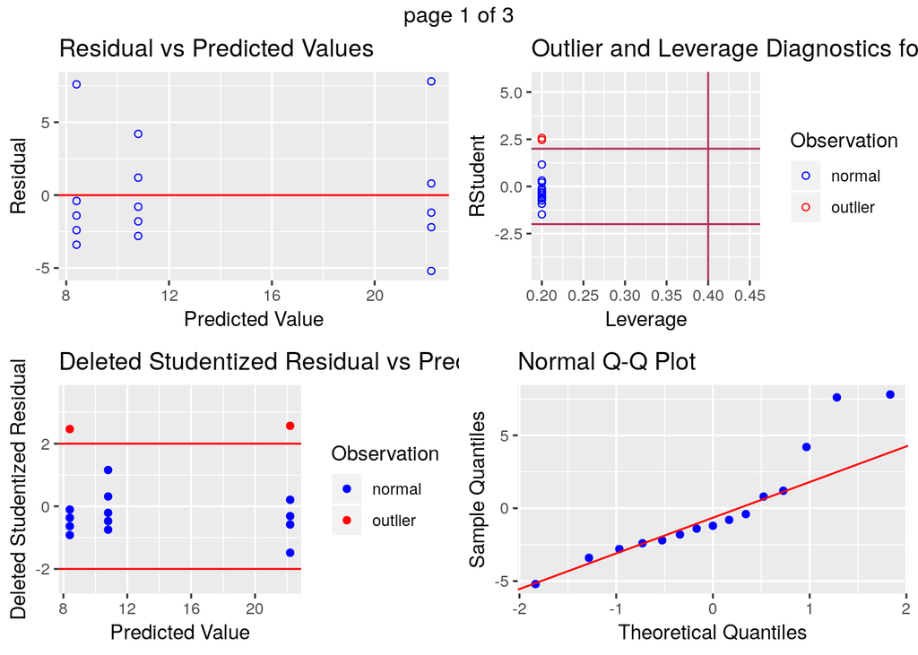

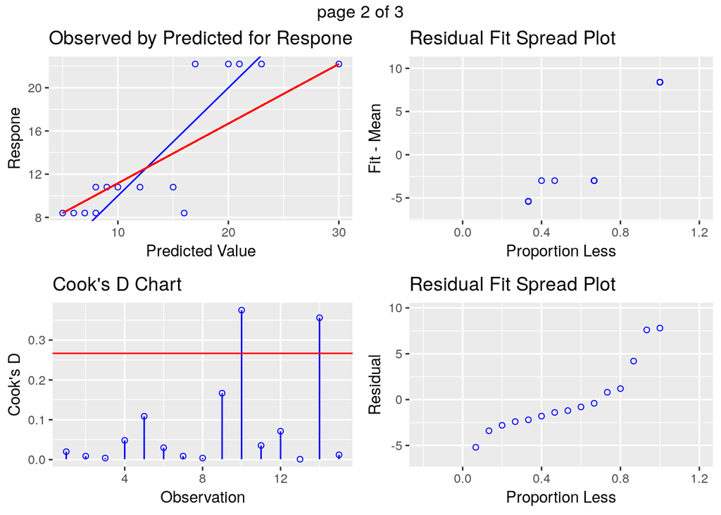

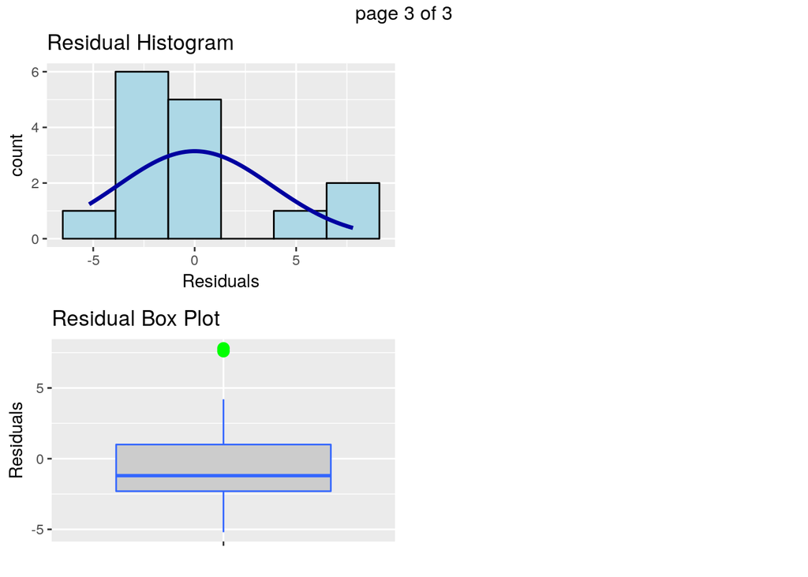

```r
ols_plot_diagnostics(lm(Respone~Type, data=table_circuit))
```

```r
bartlett.test(Respone~Type, data=table_circuit)
##
##  Bartlett test of homogeneity of variances
##
## data:  Respone by Type
## Bartlett's K-squared = 1.1345, df = 2, p-value = 0.5671
leveneTest(model_circuit)
## Warning in leveneTest.default(y = y, group = group, ...): group coerced to
## factor.
## Levene's Test for Homogeneity of Variance (center = median)
##       Df F value Pr(>F)
## group  2  0.1831  0.835
##       12
```

### Problem 6: (3.41/9 and 3.49/57)

(3.41/9) Refer to Problem 5. If we wish to detect a maximum difference in mean response times of 10 milliseconds with a probability of at least 0.90, what sample size should be used? How would you obtain a preliminary estimate of $σ^2$?

For $a=3, D=10$, the preliminary estimate $\hat\sigma^2=MS_E=16.9$.

$$Φ^2=\frac{nD^2}{2aσ^2}=\frac{n(10)^2}{2(3)(16.9)}=0.986n$$

Let $α=0.05$, accept probability $P=0.1,\nu_1=a−1=2$

The results show that when $n=5$, the power is 0.86476, when $n=6$, the power is 0.9345867. Thus, the sample size should be $n\ge6, N\ge18$.

```r
library(pwr2)
pwr.1way(k=3, n=5, alpha=0.05, f=NULL, delta=10, sigma=sqrt(16.9))
##
##      Balanced one-way analysis of variance power calculation
##
##               k = 3
##               n = 5
##           delta = 10
##           sigma = 4.110961
##     effect.size = 0.9930727
##       sig.level = 0.05
##           power = 0.86476
##
## NOTE: n is number in each group, total sample = 15 power = 0.864759967690655
pwr.1way(k=3, n=6, alpha=0.05, f=NULL, delta=10, sigma=sqrt(16.9))
##
##      Balanced one-way analysis of variance power calculation
##
##               k = 3
##               n = 6
##           delta = 10
##           sigma = 4.110961
##     effect.size = 0.9930727
##       sig.level = 0.05
##           power = 0.9345867
##
## NOTE: n is number in each group, total sample = 18 power = 0.934586703973552
```

(3.49/57) Consider the data shown in Problem 5.

1. Write out the least squares normal equations for this problem and solve them for $\hat\mu$ and $\hat\tau_i$, using the usual constraint ($\sum^3_{i=1} \hat\tau_i=0$). Estimate $\tau_1-\tau_2$

For $\sum^3_{i=1} \hat\tau_i=0$,

$$\begin{cases}\hat\tau_1+\hat\tau_2+\hat\tau_3=0\\\hat\mu+\hat\tau_1=\bar y_{1.}=10.8\\\hat\mu+\hat\tau_2=\bar y_{2.}=22.2\\\hat\mu+\hat\tau_3=\bar y_{3.}=8.4\end{cases}\implies
\begin{cases}\hat\mu=13.80\\\hat\tau_1=-3.00\\\hat\tau_2=8.40\\\hat\tau_3=-5.40\end{cases}\implies
\hat\tau_1-\hat\tau_2=-11.40$$

2. Solve the equations in (a) using the constraint $\hat\tau_3=0$. Are the estimator $\hat\tau_i$ and $\hat\mu$ the same as you found in (a)? Why? Now estimate $\tau_1-\tau_2$ and compare your answer with that for (a). What statement can you make about estimating contrasts in the $\tau_i$

$$\begin{cases}\hat\tau_3=0\\\hat\mu+\hat\tau_1=\bar y_{1.}=10.8\\\hat\mu+\hat\tau_2=\bar y_{2.}=22.2\\\hat\mu+\hat\tau_3=\bar y_{3.}=8.4\end{cases}\implies
\begin{cases}\hat\mu=8.40\\\hat\tau_1=2.40\\\hat\tau_2=13.8\\\hat\tau_3=0\end{cases}\implies
\hat\tau_1-\hat\tau_2=-11.40$$

The result shows the value of $\hatτ_1-\hatτ_2$ is irrelevant with the value of $\hatτ_3$. The contrasts are estimable.

3. Estimate $\mu+\tau_1$, $2\tau_1-\tau_2-\tau_3$, and $\mu+\tau_1+\tau_2$ using the two solutions to the normal equations. Compare the results obtained in each case.

| Contrast | Estimated from Part (a) | Estimated from Part (b) |
| --- | --- | --- |
| $\mu+\tau_1$ | 10.80 | 10.80 |
| $2\tau_1-\tau_2-\tau_3$ | -9.00 | -9.00 |
| $\mu+\tau_1+\tau_2$ | 19.20 | 24.60 |

The result shows that $\tau_1$ is independent with $\tau_3$, $\tau_1$ is independent with $\tau_2$ and $\tau_3$, while $\tau_1$ and $\tau_2$ is dependent with $\tau_3$.

## HW2

### Problem 1 (4.9-29)

Three different washing solutions are being compared to study their effectiveness in retarding bacteria growth in 5-gallon milk containers. The analysis is done in a laboratory, and only three trials can be run on any day. Because days could represent a potential source of variability, the experimenter decides to use a randomized block design. Observations are taken for four days, and the data are shown here. Analyze the data from this experiment (use $\alpha = 0.05$) and draw conclusions.

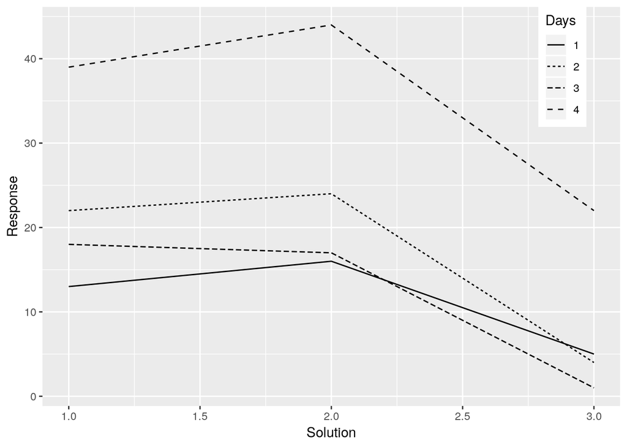

```
## Observations: 12
## Variables: 3
## $ Days     <fct> 1, 1, 1, 2, 2, 2, 3, 3, 3, 4, 4, 4
## $ Solution <fct> 1, 2, 3, 1, 2, 3, 1, 2, 3, 1, 2, 3
## $ Response <dbl> 13, 16, 5, 22, 24, 4, 18, 17, 1, 39, 44, 22
```

- The overall results

The ANOVA for RCBD shows that both treatments of solutions and blocks of days have significant effects on the average values of bacteria growth at 0.05 significant level. The P-value for treatment is 0.000323 while it for days is 0.000192.

The results of estimating regression coefficients show the P-value of Solution1 and Days1(0.000291), Solution3(0.000359), Days4(0.0000627) are small enough, while the P-value of Solution2(0.320563), Days2(0.067976), and Days3(0.790493) are larger than 0.05. The coefficients of Solution1, Days1, Solution3, Days4 are significant at 0.05 significant level. The rest are not.

- Comparing the treatment effects

The plot of LSD test shows the average response value for Solution3 has a different interval with that for other solutions. The Tukey test also shows the average response values for Solution3 are significant different with Solution1(P-value=0.0008758) and Solution2(P-value=0.0004067) at 0.05 significant level, while there is not significant difference between the average response values for Solution1 and Solution2(P-value=0.5577862) at 0.05 significant level.

However, the results by another code “pairw.anova” didn’t reveal significant difference among the three solutions in both LSD and Tukey methods. I’m still looking for the reason.

- Comparing the block effects

The plot of LSD test shows the average response value for Days4 has a different interval with that for other Days. The Tukey test also shows the average response values for Days4 are significant different with Days1(P-value=0.0002622,), Days2(P-value=0.0010843) and Days3(P-value=0.0003081) at 0.05 significant level, while there is not significant difference between the average response values for Days1, Days2, and Days3(P-value: 1-2=0.2193500, 1-3=0.9917442, 2-3=0.3037891) at 0.05 significant level.

Using the code “pairw.anova”, The LSD method gave the same result with “TukeyHSD” but the Tukey method didn’t find significant difference among the four days at 0.05 significant level. I’m still looking for the reason.

- Model adequacy Checking

- The initial conculsion

Based on the experimental data, we found Solution3 has a stronger effectiveness in retarding bacteria growth in 5-gallon milk containers. Meanwhile, the data in Days4 are significant different with others. Next step, We suggest to investigate the factors affecting the data, refine the design, and repeat the experiment.

```r
model_wash <- aov(Response~Solution+Days, data=table_wash)
summary(model_wash)
```

```
##             Df Sum Sq Mean Sq F value   Pr(>F)
## Solution     2  703.5   351.8   40.72 0.000323 ***
## Days         3 1106.9   369.0   42.71 0.000192 ***
## Residuals    6   51.8     8.6
## ---
## Signif. codes:  0 '***' 0.001 '**' 0.01 '*' 0.05 '.' 0.1 ' ' 1
```

```r
summary.lm(model_wash)
```

```
##
## Call:
## aov(formula = Response ~ Solution + Days, data = table_wash)
##
## Residuals:
##    Min     1Q Median     3Q    Max
## -2.583 -1.854 -0.250  1.250  4.417
##
## Coefficients:
##             Estimate Std. Error t value Pr(>|t|)
## (Intercept)  15.5833     2.0783   7.498 0.000291 ***
## Solution2     2.2500     2.0783   1.083 0.320563
## Solution3   -15.0000     2.0783  -7.217 0.000359 ***
## Days2         5.3333     2.3998   2.222 0.067976 .
## Days3         0.6667     2.3998   0.278 0.790493
## Days4        23.6667     2.3998   9.862 6.27e-05 ***
## ---
## Signif. codes:  0 '***' 0.001 '**' 0.01 '*' 0.05 '.' 0.1 ' ' 1
##
## Residual standard error: 2.939 on 6 degrees of freedom
## Multiple R-squared:  0.9722, Adjusted R-squared:  0.949
## F-statistic: 41.91 on 5 and 6 DF,  p-value: 0.0001371
```

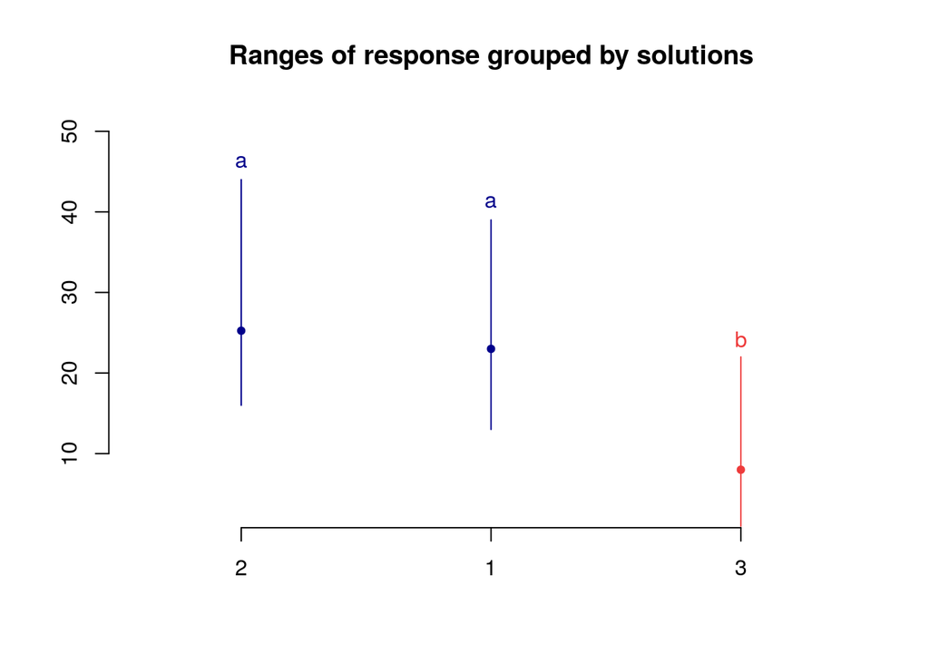

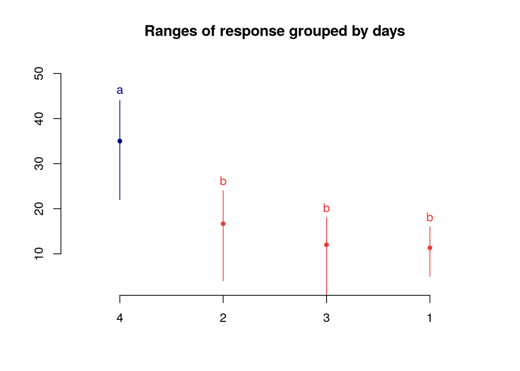

```r
# Plot for solutions and days
plot(LSD.test(model_wash, trt="Solution",alpha = 0.05,p.adj="bonferroni"),main="Ranges of response grouped by solutions")
plot(LSD.test(aov(Response~Days+Solution, data=table_wash), trt="Days",alpha = 0.05,p.adj="bonferroni"),main="Ranges of response grouped by days")
```

```r
# Comparison of solutions
TukeyHSD(model_wash,conf.level = 0.95)
```

```
##   Tukey multiple comparisons of means
##     95% family-wise confidence level
##
## Fit: aov(formula = Response ~ Solution + Days, data = table_wash)
##
## $Solution
##       diff        lwr        upr     p adj
## 2-1   2.25  -4.126879   8.626879 0.5577862
## 3-1 -15.00 -21.376879  -8.623121 0.0008758
## 3-2 -17.25 -23.626879 -10.873121 0.0004067
##
## $Days
##           diff        lwr       upr     p adj
## 2-1  5.3333333  -2.974240 13.640906 0.2193500
## 3-1  0.6666667  -7.640906  8.974240 0.9917442
## 4-1 23.6666667  15.359094 31.974240 0.0002622
## 3-2 -4.6666667 -12.974240  3.640906 0.3037891
## 4-2 18.3333333  10.025760 26.640906 0.0010843
## 4-3 23.0000000  14.692427 31.307573 0.0003081
```

```r
pairw.anova(table_wash$Response,table_wash$Solution, conf.level = 0.95, method = "lsd", MSE = NULL, df.err = NULL, control = NULL)
```

```
##
## 95% LSD confidence intervals
##
##             LSD  Diff    Lower   Upper Decision Adj. p-value
## mu1-mu2 18.1502 -2.25 -20.4002 15.9002   FTR H0      0.78549
## mu1-mu3 18.1502    15  -3.1502 33.1502   FTR H0      0.09437
## mu2-mu3 18.1502 17.25  -0.9002 35.4002   FTR H0      0.06004
```

```r
pairw.anova(table_wash$Response,table_wash$Solution, conf.level = 0.95, method = "tukey", MSE = NULL, df.err = NULL, control = NULL)
```

```
##
## 95% Tukey-Kramer confidence intervals
##
##          Diff     Lower    Upper Decision Adj. p-value
## mu1-mu2 -2.25 -24.65139 20.15139   FTR H0     0.957777
## mu1-mu3    15  -7.40139 37.40139   FTR H0     0.202758
## mu2-mu3 17.25  -5.15139 39.65139   FTR H0     0.134327
```

```r
# Comparison of days
pairw.anova(table_wash$Response,table_wash$Days, conf.level = 0.95, method = "lsd", MSE = NULL, df.err = NULL, control = NULL)
```

```
##
## 95% LSD confidence intervals
##
##              LSD      Diff     Lower    Upper  Decision Adj. p-value
## mu1-mu2 18.29527  -5.33333  -23.6286 12.96194    FTR H0      0.52037
## mu1-mu3 18.29527  -0.66667 -18.96194  17.6286    FTR H0       0.9351
## mu2-mu3 18.29527   4.66667  -13.6286 22.96194    FTR H0      0.57262
## mu1-mu4 18.29527 -23.66667 -41.96194  -5.3714 Reject H0      0.01752
## mu2-mu4 18.29527 -18.33333  -36.6286 -0.03806 Reject H0      0.04963
## mu3-mu4 18.29527       -23 -41.29527 -4.70473 Reject H0      0.01992
```

```r
pairw.anova(table_wash$Response,table_wash$Days, conf.level = 0.95, method = "tukey", MSE = NULL, df.err = NULL, control = NULL)
```

```
##
## 95% Tukey-Kramer confidence intervals
##
##              Diff     Lower    Upper Decision Adj. p-value
## mu1-mu2  -5.33333    -30.74 20.07334   FTR H0     0.904692
## mu1-mu3  -0.66667 -26.07334    24.74   FTR H0     0.999768
## mu2-mu3   4.66667    -20.74 30.07334   FTR H0     0.932872
## mu1-mu4 -23.66667 -49.07334     1.74   FTR H0     0.068128
## mu2-mu4 -18.33333    -43.74  7.07334   FTR H0     0.174505
## mu3-mu4       -23 -48.40667  2.40667   FTR H0     0.076716
```

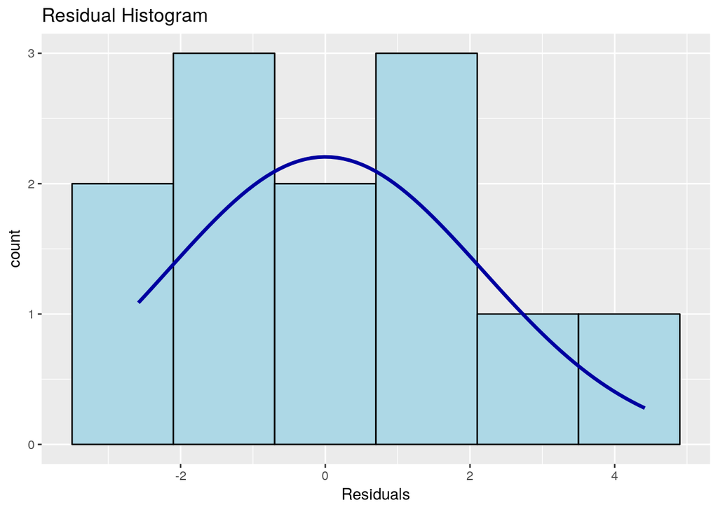

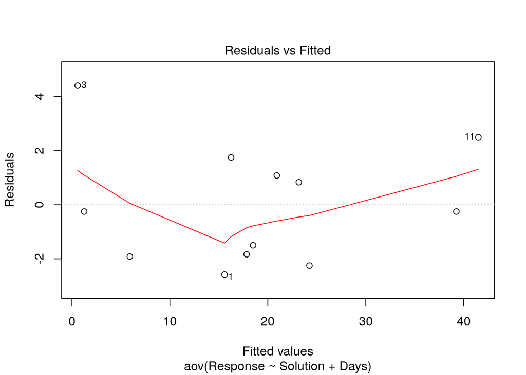

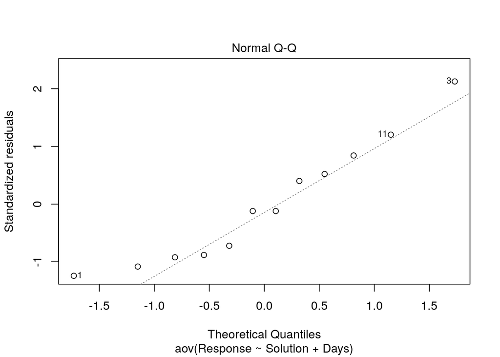

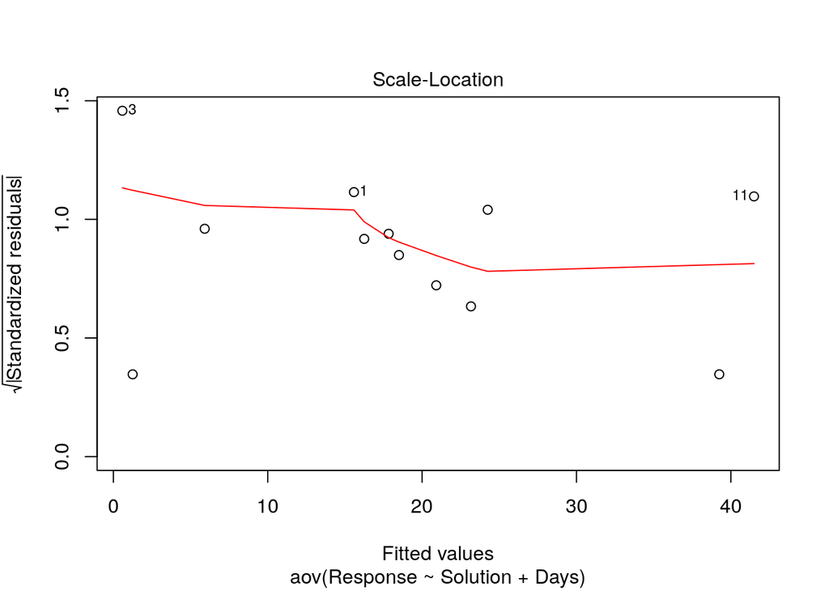

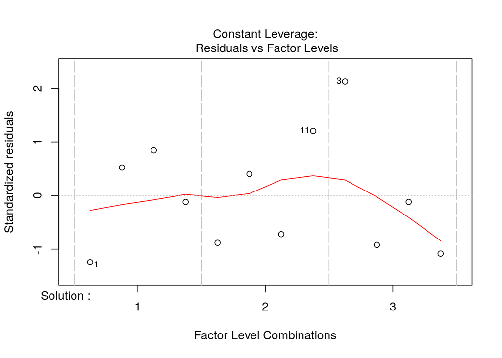

```r
ols_test_normality(lm(Response~Solution+Days, data=table_wash))
## -----------------------------------------------
##        Test             Statistic       pvalue
## -----------------------------------------------
## Shapiro-Wilk              0.9321         0.4027
## Kolmogorov-Smirnov        0.1719         0.8134
## Cramer-von Mises          0.9861         0.0020
## Anderson-Darling          0.328          0.4640
## -----------------------------------------------
ols_plot_resid_hist(lm(Response~Solution+Days, data=table_wash))
plot(model_wash)
```

—

4.29 Consider the randomized complete block design in Problem 4.9. Assume that the days are random. Estimate the block variance component.

$$\hat\sigma_{Blk}^2=\frac{MS_{Blk}-MS_{E}}{a}=\frac{369-8.6}{3}=120.1333$$

```r
summary(aov(Response~Solution+Error(Days), data=table_wash))
##
## Error: Days
##           Df Sum Sq Mean Sq F value Pr(>F)
## Residuals  3   1107     369
##
## Error: Within
##           Df Sum Sq Mean Sq F value   Pr(>F)
## Solution   2  703.5   351.8   40.72 0.000323 ***
## Residuals  6   51.8     8.6
## ---
## Signif. codes:  0 '***' 0.001 '**' 0.01 '*' 0.05 '.' 0.1 ' ' 1
```

### Problem 2 (4.13)

A consumer products company relies on direct mail marketing pieces as a major component of its advertising campaigns. The company has three different designs for a new brochure and wants to evaluate their effectiveness, as there are substantial differences in costs between the three designs. The company decides to test the three designs by mailing 5000 samples of each to potential customers in four different regions of the country. Since there are known regional differences in the customer base, regions are considered as blocks. The number of responses to each mailing is as follows.

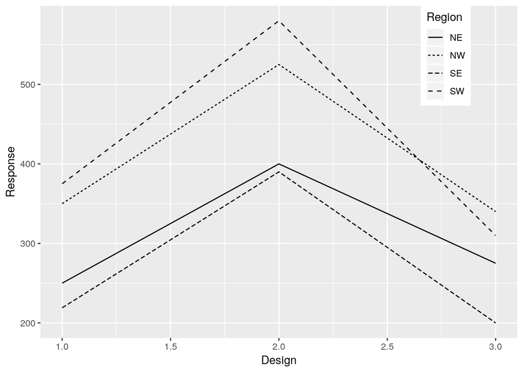

```
## Observations: 12
## Variables: 3
## $ Region   <fct> NE, NE, NE, NW, NW, NW, SE, SE, SE, SW, SW, SW
## $ Design   <fct> 1, 2, 3, 1, 2, 3, 1, 2, 3, 1, 2, 3
## $ Response <dbl> 250, 400, 275, 350, 525, 340, 219, 390, 200, 375, 580...
```

1. Analyze the data from this experiment.

```r
model_mail <- aov(Response~Design+Region, data=table_mail)
summary(model_mail)
```

```
##             Df Sum Sq Mean Sq F value  Pr(>F)
## Design       2  90755   45378   50.15 0.00018 ***
## Region       3  49036   16345   18.07 0.00208 **
## Residuals    6   5429     905
## ---
## Signif. codes:  0 '***' 0.001 '**' 0.01 '*' 0.05 '.' 0.1 ' ' 1
```

```r
summary.lm(model_mail)
```

```
##
## Call:
## aov(formula = Response ~ Design + Region, data = table_mail)
##
## Residuals:
##     Min      1Q  Median      3Q     Max
## -41.750  -3.354  -1.000   5.188  36.583
##
## Coefficients:
##             Estimate Std. Error t value Pr(>|t|)
## (Intercept)   255.67      21.27  12.020 2.01e-05 ***
## Design2       175.25      21.27   8.239 0.000173 ***
## Design3       -17.25      21.27  -0.811 0.448327
## RegionNW       96.67      24.56   3.936 0.007661 **
## RegionSE      -38.67      24.56  -1.574 0.166470
## RegionSW      113.33      24.56   4.615 0.003636 **
## ---
## Signif. codes:  0 '***' 0.001 '**' 0.01 '*' 0.05 '.' 0.1 ' ' 1
##
## Residual standard error: 30.08 on 6 degrees of freedom
## Multiple R-squared:  0.9626, Adjusted R-squared:  0.9315
## F-statistic:  30.9 on 5 and 6 DF,  p-value: 0.0003285
```

2. Use the Fisher LSD method to make comparisons among the three designs to determine specifically which designs differ in the mean response rate.

The plot of LSD test shows the average response value for Design2 has a different interval with that for other designs. The LSD test using “pairw.anova” also shows the average response values for Design2 are significant different with Design1(P-value=0.01108) and Design3(P-value=0.00673) at 0.05 significant level, while there is not significant difference between the average response value for Design1 and Design3(P-value=0.76098) at 0.05 significant level.

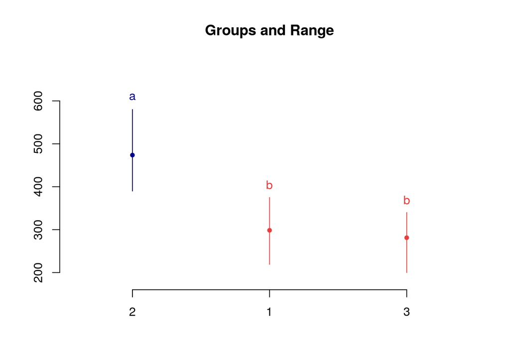

```r
plot(LSD.test(model_mail, trt="Design",alpha = 0.05,p.adj="bonferroni"))
```

```r
pairw.anova(table_mail$Response,table_mail$Design, conf.level = 0.95, method = "lsd", MSE = NULL, df.err = NULL, control = NULL)
##
## 95% LSD confidence intervals
##
##               LSD    Diff      Lower     Upper  Decision Adj. p-value
## mu1-mu2 124.43521 -175.25 -299.68521 -50.81479 Reject H0      0.01108
## mu1-mu3 124.43521   17.25 -107.18521 141.68521    FTR H0      0.76098
## mu2-mu3 124.43521   192.5   68.06479 316.93521 Reject H0      0.00673
```

3. Analyze the residuals from this experiment.
- Model adequacy Checking

- After transformation

The ANOVA for RCBD shows simular results. Moreover, MSE after transformation(0.502) is much smaller than before(905). The P-value is smaller too (0.000106 for treatment, 0.000986 for blocks).

The results of paried test are same. The plot of LSD test shows the average response value for Design2 has a different interval with that for other designs. The LSD test using “pairw.anova” also shows the average response values for Design2 are significant different with Design1(P-value=0.01333) and Design3(P-value=0.00792) at 0.05 significant level, while there is not significant difference between Design1 and Design3(P-value=0.7525) at 0.05 significant level.

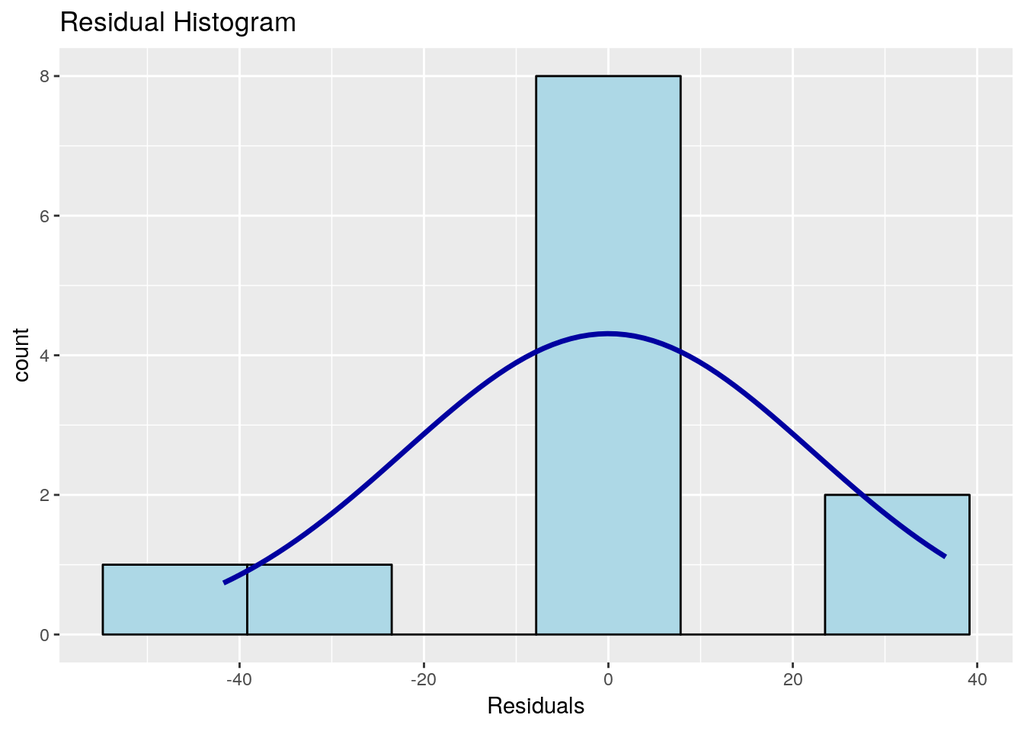

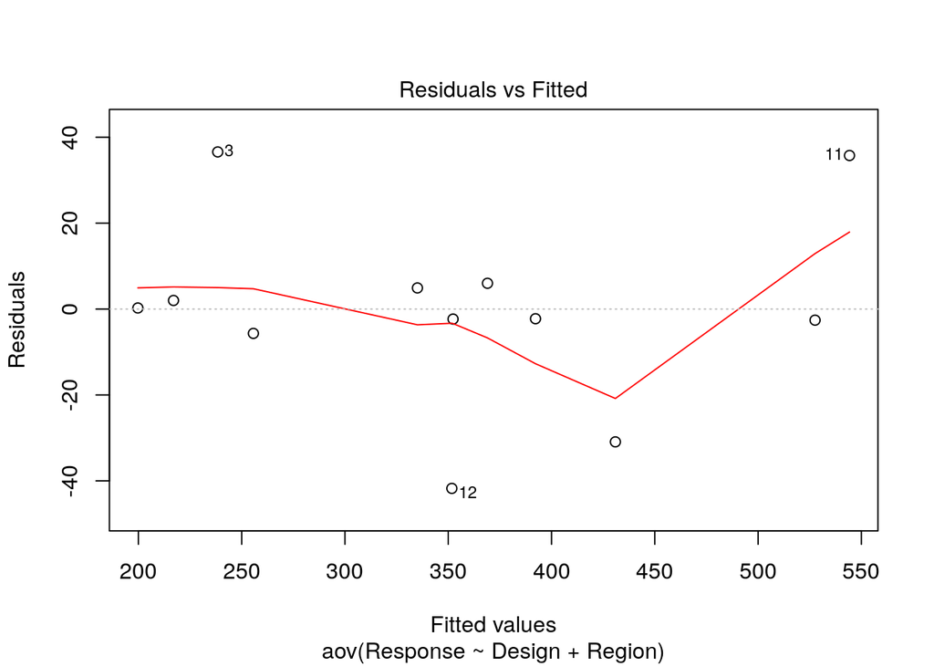

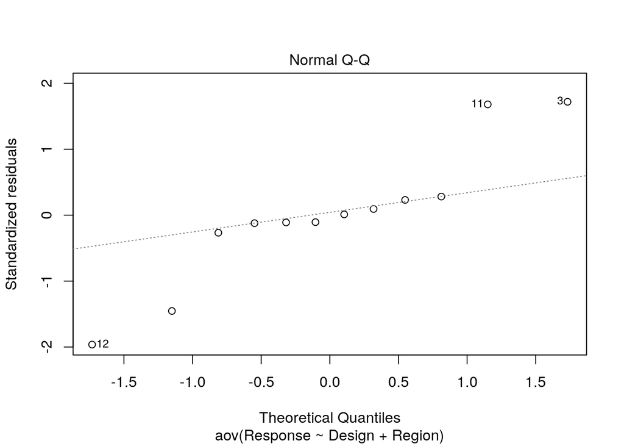

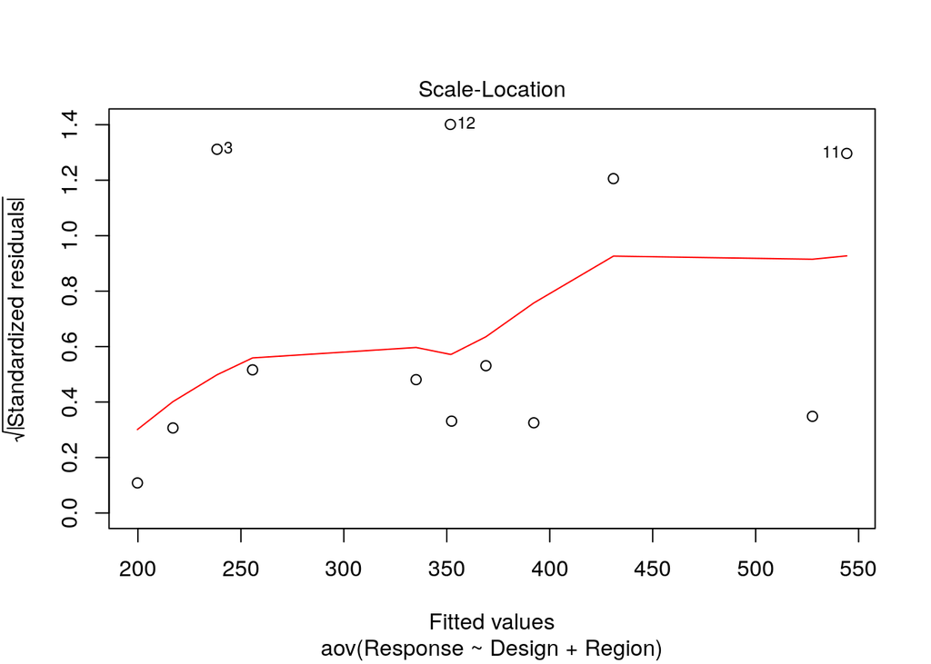

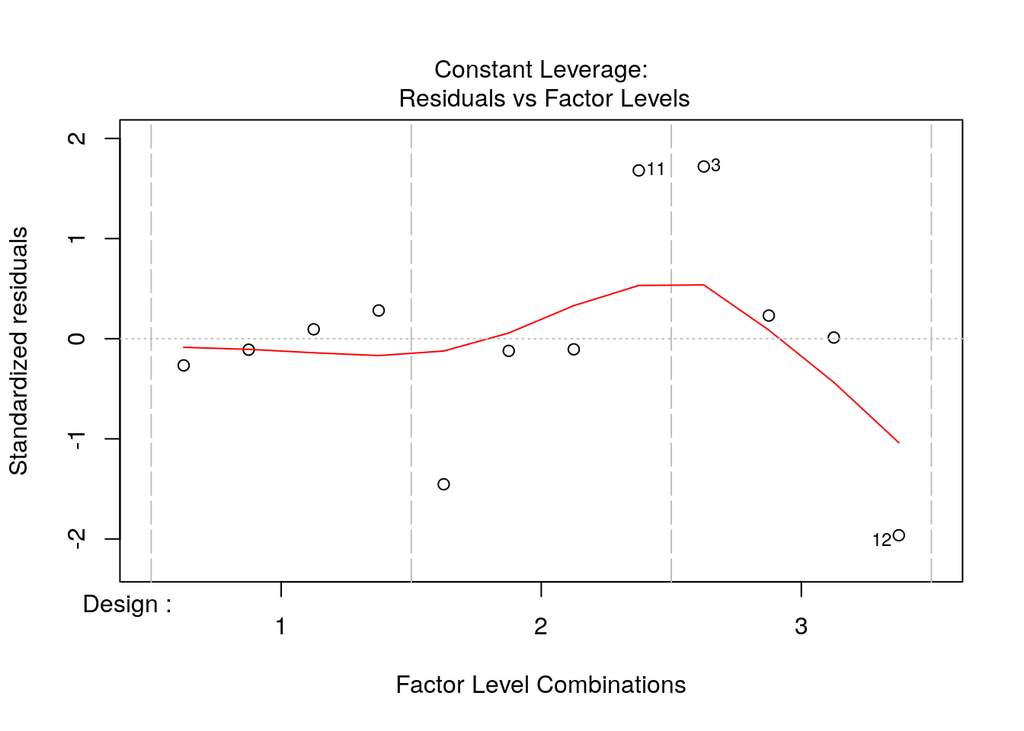

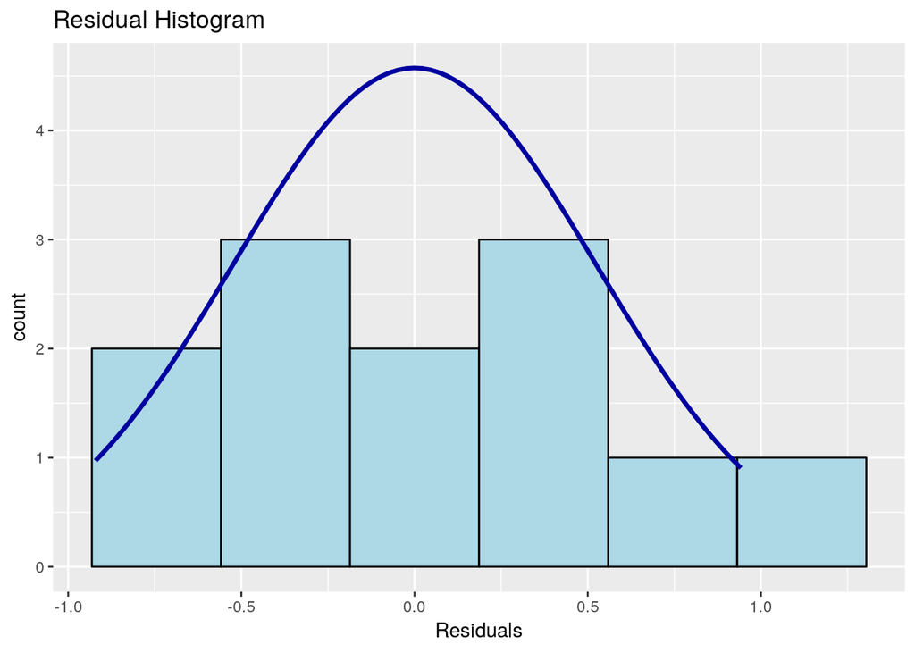

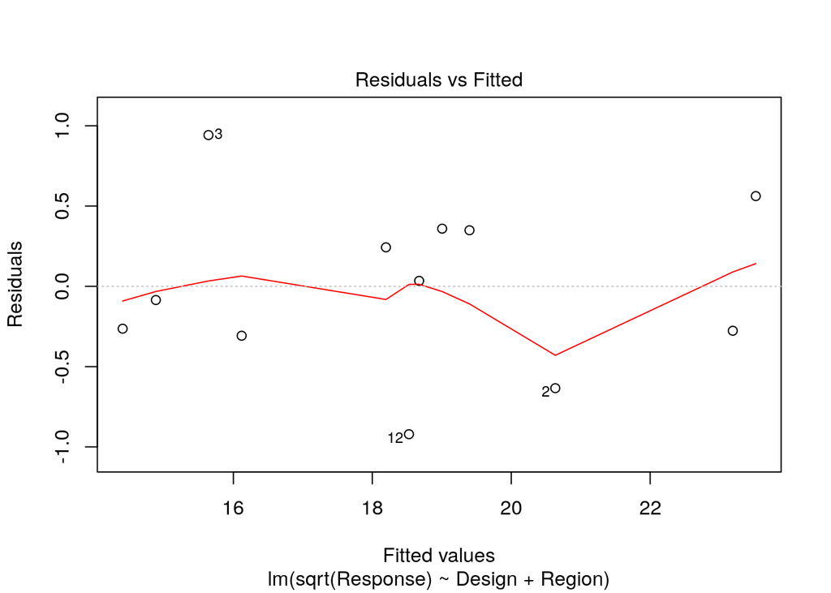

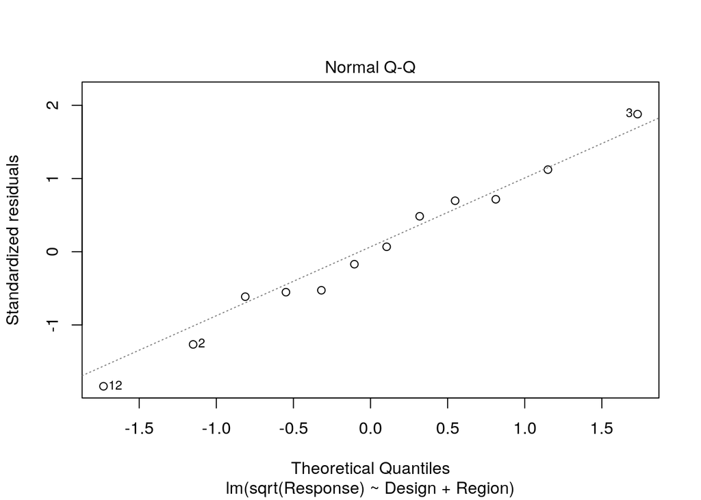

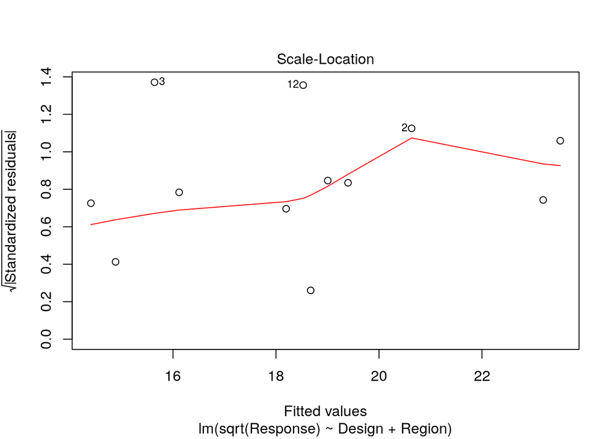

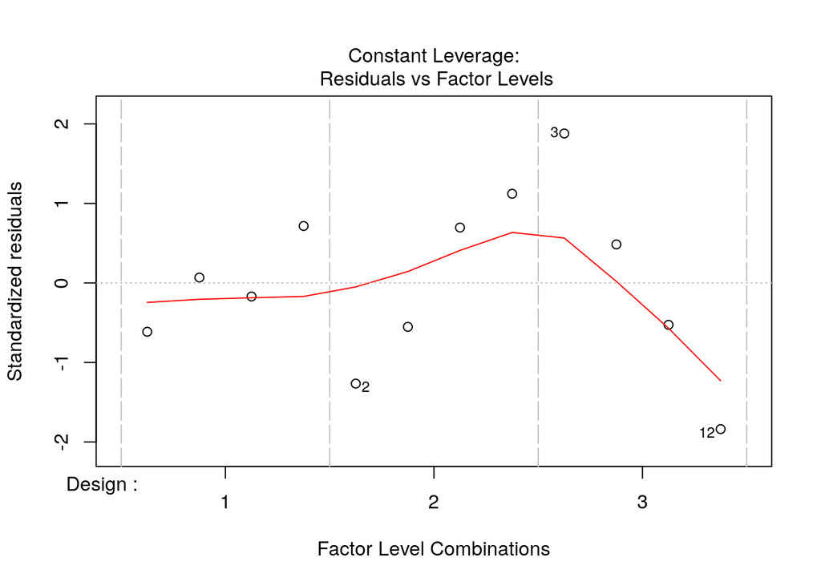

```r
ols_test_normality(lm(Response~Design+Region, data=table_mail))
## -----------------------------------------------
##        Test             Statistic       pvalue
## -----------------------------------------------
## Shapiro-Wilk              0.8887         0.1133
## Kolmogorov-Smirnov        0.2327         0.4654
## Cramer-von Mises          0.875          0.0039
## Anderson-Darling          0.7294         0.0414
## -----------------------------------------------
ols_test_normality(lm(sqrt(Response)~Design+Region, data=table_mail))
## -----------------------------------------------
##        Test             Statistic       pvalue
## -----------------------------------------------
## Shapiro-Wilk              0.9865         0.9981
## Kolmogorov-Smirnov        0.1116         0.9941
## Cramer-von Mises          1.3217          2e-04
## Anderson-Darling          0.1502         0.9464
## -----------------------------------------------
ols_plot_resid_hist(lm(Response~Design+Region, data=table_mail))
plot(model_mail)
ols_plot_resid_hist(lm(sqrt(Response)~Design+Region, data=table_mail))
plot(lm(sqrt(Response)~Design+Region, data=table_mail))
```

```r
model_mail_sqrt <- aov(sqrt(Response)~Design+Region, data=table_mail)
summary(model_mail_sqrt)
```

```
##             Df Sum Sq Mean Sq F value   Pr(>F)
## Design       2  60.73  30.367   60.47 0.000106 ***
## Region       3  35.89  11.964   23.82 0.000986 ***
## Residuals    6   3.01   0.502
## ---
## Signif. codes:  0 '***' 0.001 '**' 0.01 '*' 0.05 '.' 0.1 ' ' 1
```

```r
summary.lm(model_mail_sqrt)
```

```
##
## Call:
## aov(formula = sqrt(Response) ~ Design + Region, data = table_mail)
##
## Residuals:
##      Min       1Q   Median       3Q      Max
## -0.92104 -0.28449 -0.02568  0.35161  0.94207
##
## Coefficients:
##             Estimate Std. Error t value Pr(>|t|)
## (Intercept)  16.1191     0.5011  32.168    6e-08 ***
## Design2       4.5153     0.5011   9.011 0.000105 ***
## Design3      -0.4780     0.5011  -0.954 0.376944
## RegionNW      2.5552     0.5786   4.416 0.004490 **
## RegionSE     -1.2351     0.5786  -2.135 0.076721 .
## RegionSW      2.8868     0.5786   4.989 0.002479 **
## ---
## Signif. codes:  0 '***' 0.001 '**' 0.01 '*' 0.05 '.' 0.1 ' ' 1
##
## Residual standard error: 0.7087 on 6 degrees of freedom
## Multiple R-squared:  0.9698, Adjusted R-squared:  0.9446
## F-statistic: 38.48 on 5 and 6 DF,  p-value: 0.0001754
```

```r
# plot(LSD.test(model_mail_sqrt, trt="Design",alpha = 0.05,p.adj="bonferroni"))
pairw.anova(sqrt(table_mail$Response),table_mail$Design, conf.level = 0.95, method = "lsd")
##
## 95% LSD confidence intervals
##
##             LSD     Diff    Lower    Upper  Decision Adj. p-value
## mu1-mu2 3.32573 -4.51531 -7.84104 -1.18958 Reject H0      0.01333
## mu1-mu3 3.32573  0.47802 -2.84771  3.80375    FTR H0       0.7525
## mu2-mu3 3.32573  4.99333   1.6676  8.31906 Reject H0      0.00792
```

### Problem 3

$y_{ijkl}=μ+τ_i+α_{j(l)}+β_k+δ_l+ε_{ijkl}$ for $i,j,k =1,…,p$ ; $l=1,…,n$; $ε_{ijkl}\sim iid N(0,σ^2 )$ Derive the parameter estimates from the least squares method using the constrains $\sum_i\hat\tau_i=0;\ \sum_j\hat\alpha_{j(l)}=0;\ \sum_l\hat\alpha_{j(l)}=0;\ \sum_k\hat\beta_k=0;\ \sum_l\hat\delta_l=0$

$$SSE=\sum_i^p\sum_j^p\sum_k^p\sum_l^n(y_{ijkl}-μ-τ_i-α_{j(l)}-β_k-δ_l)^2$$

Derive

$\left.\frac{\partial SSE}{\partial μ}\right|_{\hatμ,\hatτ_i,\hatα_{j(l)},\hatβ_k,\hatδ_l}=2\sum_i^p\sum_j^p\sum_k^p\sum_l^n(y_{ijkl}-\hatμ-\hatτ_i-\hatα_{j(l)}-\hatβ_k-\hatδ_l)(-1)=0$

$\left.\frac{\partial SSE}{\partial τ_i}\right|_{\hatμ,\hatτ_i,\hatα_{j(l)},\hatβ_k,\hatδ_l}=2\sum_j^p\sum_k^p\sum_l^n(y_{ijkl}-\hatμ-\hatτ_i-\hatα_{j(l)}-\hatβ_k-\hatδ_l)(-1)=0$

$\left.\frac{\partial SSE}{\partial α_{j(l)}}\right|_{\hatμ,\hatτ_i,\hatα_{j(l)},\hatβ_k,\hatδ_l}=2\sum_i^p\sum_k^p(y_{ijkl}-\hatμ-\hatτ_i-\hatα_{j(l)}-\hatβ_k-\hatδ_l)(-1)=0$

$\left.\frac{\partial SSE}{\partial β_k}\right|_{\hatμ,\hatτ_i,\hatα_{j(l)},\hatβ_k,\hatδ_l}=2\sum_i^p\sum_j^p\sum_l^n(y_{ijkl}-\hatμ-\hatτ_i-\hatα_{j(l)}-\hatβ_k-\hatδ_l)(-1)=0$

$\left.\frac{\partial SSE}{\partial δ_l}\right|_{\hatμ,\hatτ_i,\hatα_{j(l)},\hatβ_k,\hatδ_l}=2\sum_i^p\sum_j^p\sum_k^p(y_{ijkl}-\hatμ-\hatτ_i-\hatα_{j(l)}-\hatβ_k-\hatδ_l)(-1)=0$

$$\left\{\begin{array}{l}
y_{....}=np^2\hatμ+np\sum_i^p\hatτ_i+p^2\sum_j^p\sum_l^n\hatα_{j(l)}+np\sum_k^p\hatβ_k+p^2\sum_l^n\hatδ_l\\
y_{i...}=np\hatμ+np\hatτ_i+p\sum_j^p\sum_l^n\hatα_{j(l)}+np\sum_k^p\hatβ_k+p^2\sum_l^n\hatδ_l \\
y_{.j.l}=p\hatμ+p\sum_i^p\hatτ_i+p\hatα_{j(l)}+p\sum_k^p\hatβ_k+p\hatδ_l \\
y_{..k.}=np\hatμ+n\sum_i^p\hatτ_i+\sum_j^p\sum_l^n\hatα_{j(l)}+np\hatβ_k+p\sum_l^n\hatδ_l \\
y_{...l}=p^2\hatμ+p^2\sum_i^p\hatτ_i+p^2\sum_j^p\hatα_{j(l)}+p^2\sum_k^p\hatβ_k+p^2\hatδ_l\\
\end{array}\right.$$

For $\sum_i\hat\tau_i=0;\ \sum_j\hat\alpha_{j(l)}=0;\ \sum_l\hat\alpha_{j(l)}=0;\ \sum_k\hat\beta_k=0;\ \sum_l\hat\delta_l=0$,

and for $\hatμ$ is constant, $\hatτ_i,\hatα_{j(l)},\hatβ_k,\hatδ_l$ are constants for summations on other parameters,

and for $y_{....}=np^2 \bar y_{....}=np\bar y_{i...}=np\bar y_{.j..}=np\bar y_{..k.}=p^2\bar y_{...l}$,

and for $y_{i...}=np\bar y_{i...}$, $y_{.j.l}=p\bar y_{.j.l}$, $y_{..k.}=np\bar y_{..k.}$, $y_{...l}=p^2\bar y_{...l}$, then

$$\left\{\begin{array}{l}\ np^2\bar y_{....}=np^2\hatμ+0+0+0+0\\
np\bar y_{i...}=np\hatμ+np\hatτ_i+0+0+0 \\
p\bar y_{.j.l}=p\hatμ+0+p\hatα_{j(l)}+0+p\hatδ_l \\
np\bar y_{..k.}=np\hatμ+0+0+np\hatβ_k+0 \\
p^2\bar y_{...l}=p^2\hatμ+0+0+0+p^2\hatδ_l \end{array}\right.
\implies
\left\{\begin{array}{l}\ \hatμ=\bar y_{....}\\
\hatτ_i=\bar y_{i...}-\bar y_{....}\\
\hatα_{j(l)}=\bar y_{.j.l}-\bar y_{...l} \\
\hatβ_k=\bar y_{..k.}-\bar y_{....} \\
\hatδ_l=\bar y_{...l}-\bar y_{....} \end{array}\right.$$

## HW3

### Problem 1: RCBD with one missing observation

Winter road treatments to clear snow and ice can lead to cracking in the pavement. An experiment was conducted comparing 4 treatments: sodium chloride (A), calcium chloride (B), a proprietary organic compound (C), and sand (D). Traffic level was used as a blocking factor and a randomized complete block experiment was conducted. One observation is missing, because the spreader in that district was no operating properly. The response is new cracks per mile of treated roadway.

1. Compute the mean response for each treatment and report here. You may copy and paste output table from your software here.

```
##  A  B  C  D
## 39 45 28 32
```

2. Compute the mean response for each block and report here. You may copy and paste output table from your software here.

```
##   Block1   Block2   Block3
## 31.66667 38.50000 36.00000
```

3. Compute the overall mean response and report here.

```
## [1] 35.72727
```

4. Use the approximation method learned to estimate one missing value in Chapter 4 and estimate the value of the missing observation. Report it here. Show any computation here.

$$\hat x=\frac{ay'_{1.}+by'_{.1}-y'_{..}}{(a-1)(b-1)}=\frac{3*95+4*78-393}{(3-1)(4-1)}=34$$

5. Include that estimated missing value in the given data file appropriately and obtain an ANOVA table for this design. Report ONLY the ANOVA table here.

```
##             Df Sum Sq Mean Sq F value Pr(>F)
## trt          3  486.3  162.08   1.055  0.435
## blk          2   79.2   39.58   0.258  0.781
## Residuals    6  921.5  153.58
```

6. Now, adjust the degrees of freedom for error in the ANOVA table for one missing value. (See the Chapter 4 note). And use adjusted df of error to compute the correct p-value for testing significance of treatments. Write your conclusion based on your p value and report the p value here.

$$F_{adj}=\frac{MS_{Trt}}{SSE/dfE_{adj}}=\frac{162.08}{921.5/(6-1)}=0.8794357$$
The adjusted P-value is 0.5111382.

Both of the ANOVA for RCBD of original data and adjusted data show that 4 treatments have not significant effects on the average values of cracking in the pavement at 0.05 significant level. The P-value for treatment with missing observation is 0.435 while adjusted P-value is 0.5111 and 0.5141 in two methods. This means we should use adjusted methods to avoid the type I error (the rejection of a true null hypothesis) for RCBD with one missing observation.

7. The second method of analyzing data with missing value is extra (partial) sum of squares method. Fit a multiple linear regression model and obtain the extra (partial) sum of squares for treatments. If you forgot how to do this, look at regression analysis labs and notes. Test whether treatment is a significant factor using extra (partial) SS F test. Report the p-value from extra (partial) SS F test.

$$F_0=\frac{\frac{SSE_{reduced}-SSE_{full}}{dfE_{reduced}-dfE_{full}}}{MSE_{full}}=\frac{1403.7-921.5}{184.30*(a-1)}=0.8721288$$

The adjusted P-value is 0.5141271. the result shows the same conculsion with apporximation method.

We find the P-value in the Apporximation method is smaller than the Exact method because the first method is that minimizing only $SSE$ may increasing $SS_{Trt}$ and hence it is more likely to conclude effects are significant when they are actually not.

8. Report the complete code along with output here.

```r
# (e)
table_complete <- tibble(y=c(34,32,27,36,38,40,43,33,40,63,14,27),trt=rep(c("A","B","C","D"),3),blk=c(rep("Block1",4),rep("Block2",4),(rep("Block3",4))))
summary(aov(y~trt+blk,data=table_complete))
##             Df Sum Sq Mean Sq F value Pr(>F)
## trt          3  486.3  162.08   1.055  0.435
## blk          2   79.2   39.58   0.258  0.781
## Residuals    6  921.5  153.58
# (f)
1-pf(0.8794357, 3, 5, lower.tail = TRUE, log.p = FALSE)
## [1] 0.5111382
# (g)
table_miss1 <- tibble(y=c(NA,32,27,36,38,40,43,33,40,63,14,27),trt=rep(c("A","B","C","D"),3),blk=c(rep("Block1",4),rep("Block2",4),(rep("Block3",4))))
summary(aov(y~trt+blk,data=table_miss1))
##             Df Sum Sq Mean Sq F value Pr(>F)
## trt          3  500.2  166.73   0.905  0.501
## blk          2   62.5   31.25   0.170  0.849
## Residuals    5  921.5  184.30
## 1 observation deleted due to missingness
summary(aov(y~blk,data=table_miss1))
##             Df Sum Sq Mean Sq F value Pr(>F)
## blk          2   80.5   40.26   0.229    0.8
## Residuals    8 1403.7  175.46
## 1 observation deleted due to missingness
1-pf(0.8721288, 3, 5, lower.tail = TRUE, log.p = FALSE)
## [1] 0.5141271
```

### Problem 2 (4.22/27)

The effect of five different ingredients (A, B, C, D, E) on the reaction time of a chemical process is being studied. Each batch of new material is only large enough to permit five runs to be made. Furthermore, each run requires approximately 3/2 hours, so only five runs can be made in one day. The experimenter decides to run the experiment as a Latin square so that day and batch effects may be systematically controlled. She obtains the data that follow. Analyze the data from this experiment (use 𝛼 = 0.05) and draw conclusions.

1. Create plot of data and report it here.

```
## Observations: 25
## Variables: 4
## $ Batch <fct> 1, 1, 1, 1, 1, 2, 2, 2, 2, 2, 3, 3, 3, 3, 3, 4, 4, 4, 4,...
## $ Day   <fct> 1, 2, 3, 4, 5, 1, 2, 3, 4, 5, 1, 2, 3, 4, 5, 1, 2, 3, 4,...
## $ Trt   <fct> A, B, D, C, E, C, E, A, D, B, B, A, C, E, D, D, C, E, B,...
## $ y     <dbl> 8, 7, 1, 7, 3, 11, 2, 7, 3, 8, 4, 9, 10, 1, 5, 6, 8, 6, ...
```

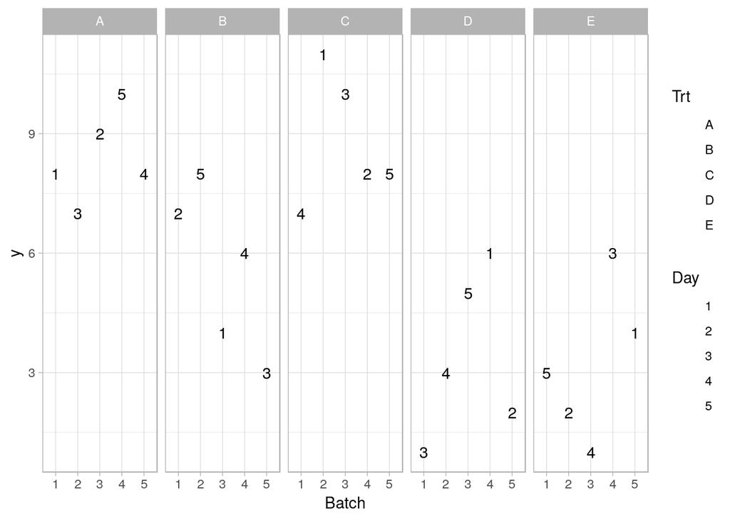

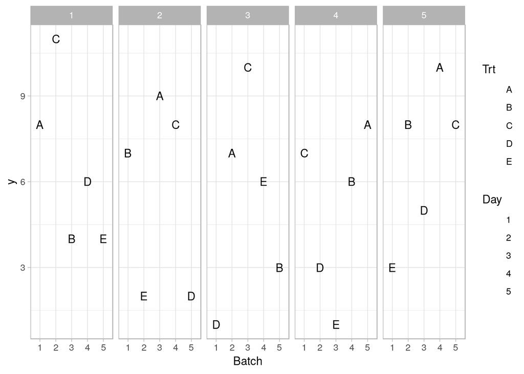

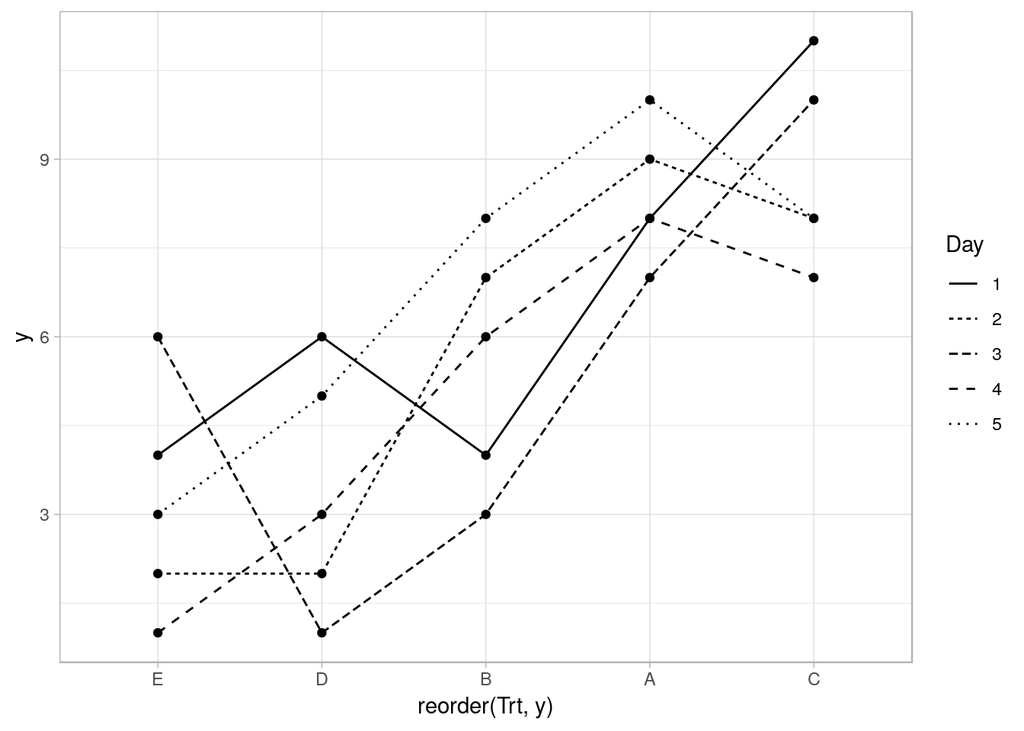

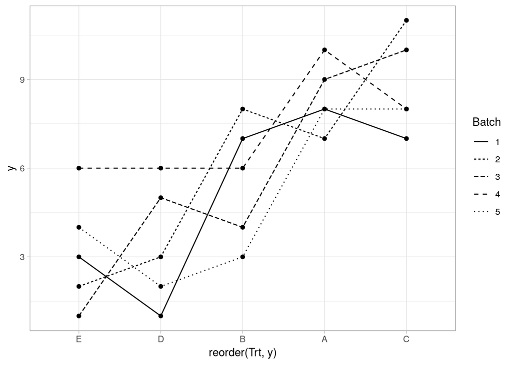